# bike_sharing1

## **PART I - FORD GOBIKE SYSTEM DATA**

## **BY ADURAGBEMI OYINLOLA**

## **INTRODUCTION**

> Ford GoBike system data; this data set includes information about individual rides made in a bike-sharing system covering the greater San Francisco Bay area. The dataset contain 183412 rows and 16 columns.

> I will be using this dataset to predict if the individual used to bike to complete the trip or not.

```python
import numpy as np
import pandas as pd
import matplotlib.pyplot as plt
import seaborn as sns
%matplotlib inline

sns.set_style('whitegrid')
```

> Packages for this project.

## **PRELIMINARY WRANGLING**

```python
bike = pd.read_csv('bike.csv')
bike.head()
```

|  | duration_sec | start_time | end_time | start_station_id | start_station_name | start_station_latitude | start_station_longitude | end_station_id | end_station_name | end_station_latitude | end_station_longitude | bike_id | user_type | member_birth_year | member_gender | bike_share_for_all_trip |
| --- | --- | --- | --- | --- | --- | --- | --- | --- | --- | --- | --- | --- | --- | --- | --- | --- |
| 0 | 52185 | 2019-02-28 17:32:10.1450 | 2019-03-01 08:01:55.9750 | 21.0 | Montgomery St BART Station (Market St at 2nd St) | 37.789625 | -122.400811 | 13.0 | Commercial St at Montgomery St | 37.794231 | -122.402923 | 4902 | Customer | 1984.0 | Male | No |
| 1 | 42521 | 2019-02-28 18:53:21.7890 | 2019-03-01 06:42:03.0560 | 23.0 | The Embarcadero at Steuart St | 37.791464 | -122.391034 | 81.0 | Berry St at 4th St | 37.775880 | -122.393170 | 2535 | Customer | NaN | NaN | No |
| 2 | 61854 | 2019-02-28 12:13:13.2180 | 2019-03-01 05:24:08.1460 | 86.0 | Market St at Dolores St | 37.769305 | -122.426826 | 3.0 | Powell St BART Station (Market St at 4th St) | 37.786375 | -122.404904 | 5905 | Customer | 1972.0 | Male | No |
| 3 | 36490 | 2019-02-28 17:54:26.0100 | 2019-03-01 04:02:36.8420 | 375.0 | Grove St at Masonic Ave | 37.774836 | -122.446546 | 70.0 | Central Ave at Fell St | 37.773311 | -122.444293 | 6638 | Subscriber | 1989.0 | Other | No |
| 4 | 1585 | 2019-02-28 23:54:18.5490 | 2019-03-01 00:20:44.0740 | 7.0 | Frank H Ogawa Plaza | 37.804562 | -122.271738 | 222.0 | 10th Ave at E 15th St | 37.792714 | -122.248780 | 4898 | Subscriber | 1974.0 | Male | Yes |

> Loaded the dataset into a variable *bike* and checked the first five rows of the data set using the *.head()* method. From the above output, the data set contains missing values.

```python
bike.shape
```

```
(183412, 16)
```

> The shape code checks the number of rows and columns of the dataset and this is 183,412 and 16 respectively.

```python
bike.info()
```

```
<class 'pandas.core.frame.DataFrame'>
RangeIndex: 183412 entries, 0 to 183411
Data columns (total 16 columns):
 #   Column                   Non-Null Count   Dtype
---  ------                   --------------   -----
 0   duration_sec             183412 non-null  int64
 1   start_time               183412 non-null  object
 2   end_time                 183412 non-null  object
 3   start_station_id         183215 non-null  float64
 4   start_station_name       183215 non-null  object
 5   start_station_latitude   183412 non-null  float64
 6   start_station_longitude  183412 non-null  float64
 7   end_station_id           183215 non-null  float64
 8   end_station_name         183215 non-null  object
 9   end_station_latitude     183412 non-null  float64
 10  end_station_longitude    183412 non-null  float64
 11  bike_id                  183412 non-null  int64
 12  user_type                183412 non-null  object
 13  member_birth_year        175147 non-null  float64
 14  member_gender            175147 non-null  object
 15  bike_share_for_all_trip  183412 non-null  object
dtypes: float64(7), int64(2), object(7)
memory usage: 22.4+ MB
```

> The output above shows the datatype of all features in the dataset and from the output, only three(3) datatypes are present in the dataset, seven(7) of the features having *float64*, two(2) features having *int64* and seven(7) having the *object* data type.

```python
bike.describe()
```

|  | duration_sec | start_station_id | start_station_latitude | start_station_longitude | end_station_id | end_station_latitude | end_station_longitude | bike_id | member_birth_year |
| --- | --- | --- | --- | --- | --- | --- | --- | --- | --- |
| count | 183412.000000 | 183215.000000 | 183412.000000 | 183412.000000 | 183215.000000 | 183412.000000 | 183412.000000 | 183412.000000 | 175147.000000 |
| mean | 726.078435 | 138.590427 | 37.771223 | -122.352664 | 136.249123 | 37.771427 | -122.352250 | 4472.906375 | 1984.806437 |
| std | 1794.389780 | 111.778864 | 0.099581 | 0.117097 | 111.515131 | 0.099490 | 0.116673 | 1664.383394 | 10.116689 |
| min | 61.000000 | 3.000000 | 37.317298 | -122.453704 | 3.000000 | 37.317298 | -122.453704 | 11.000000 | 1878.000000 |
| 25% | 325.000000 | 47.000000 | 37.770083 | -122.412408 | 44.000000 | 37.770407 | -122.411726 | 3777.000000 | 1980.000000 |
| 50% | 514.000000 | 104.000000 | 37.780760 | -122.398285 | 100.000000 | 37.781010 | -122.398279 | 4958.000000 | 1987.000000 |
| 75% | 796.000000 | 239.000000 | 37.797280 | -122.286533 | 235.000000 | 37.797320 | -122.288045 | 5502.000000 | 1992.000000 |
| max | 85444.000000 | 398.000000 | 37.880222 | -121.874119 | 398.000000 | 37.880222 | -121.874119 | 6645.000000 | 2001.000000 |

> The above output shows the descriptive statistics of numeric features in the dataset.

## **FURTHER WRANGLING**

### **MISSING VALUES**

```python
bike.isnull().sum()
```

```
duration_sec                  0
start_time                    0
end_time                      0
start_station_id            197
start_station_name          197
start_station_latitude        0
start_station_longitude       0
end_station_id              197
end_station_name            197
end_station_latitude          0
end_station_longitude         0
bike_id                       0
user_type                     0
member_birth_year          8265
member_gender              8265
bike_share_for_all_trip       0
dtype: int64
```

> The line of code above checks the features for missing values and from the output six(6) features possess missing values - _start_station_id, start_station_name, end_station_id, end_station_name, member_birth_year, member*gender*.

```python
bike = bike.dropna(axis=0)
bike.shape
```

```
(174952, 16)
```

> The line of code above removes the missing values in the dataset by rows.

```python
bike.isnull().sum().sum()
```

```
0
```

> The output above is a confirmation that all missing values in the dataset has been removed.

### **DATA TYPE FIXING**

#### **OBJECT TO DATETIME**

```python
bike[['start_time', 'end_time']].dtypes
```

```
start_time    object
end_time      object
dtype: object
```

> The _start*time* and _end*time* features of this dataset have its datatype as *object* they should be in the *datetime* format.

```python
features = ['start_time', 'end_time']

for feat in features:
    bike[feat] = pd.to_datetime(bike[feat])

for feat in features:
    print(bike[feat].dtype)
```

```
datetime64[ns]
datetime64[ns]
```

> The code cell above converts the features to *datetime* and prints out the datatype of the features and it is confirmed that the datatypes have been changed to how they should be.

#### **NUMERIC TO OBJECT**

```python
num_obj = ['start_station_id', 'end_station_id', 'bike_id']

for feat in num_obj:
    bike[feat] = bike[feat].astype(str)
```

> In the code cell above, I extracted the features that needs to be converted from the numeric data type to object data type.

> I looped through the list and converted it to the object data type.

```python
for obj in num_obj:
    print(bike[obj].dtype)
```

```
object
object
object
```

> From the above output, I checked the data type of the features I extracted and it is in data type format I want now.

#### **OBJECT TO CATEGORICAL**

```python
cat_dict = {
            'member_gender': ['Male', 'Female', 'Other']
            }

for var in cat_dict:
    cat_type = pd.api.types.CategoricalDtype(ordered=True,
                                             categories=cat_dict[var])
bike[var] = bike[var].astype(cat_type)
```

> I convert the gender of the member to categorical to help keep it ordered.

```python
for var in cat_dict:
    print(bike[var].dtype)
```

```
category
```

> The data type have been changed from object to categorical

### **What is the structure of dataset?**

> The initial shape of the dataset is 183412 row and 16 columns after cleaning on the dataset the shape of the dataset became 174952 row and 16 columns.

### **What is/are the main feature(s) of interest in your dataset?**

> The feature that interest me the most is the _bike_share_for_all*trip*, I will like to know the percentage of individuals that completed their trip using the bike and this will be done with the help of other features.

### **What features in the dataset do you think will help support your investigation into your feature(s) of interest?**

> I think features like _duration_sec, start and end of stations longitude and latitude, user_type and member*gender* will play an important role in determining if the individual completed the trip or not.

## **UNIVARIATE EXPLORATION**

> For the univariate plot, I have decided to start with the **numeric** features in the dataset first. I will be starting with the distribution of the duration in seconds the individual used the bike.

```python
def hist(data, x, bins):
    plt.hist(data[x], bins=bins)
    plt.title(f'Distribution of {x}', size=15)
    plt.xlabel(x, size=12)
```

> I created a function named *hist* to make my histograms. The histogram shows a distribution of the numeric features in my dataset.

### **QUESTION:**

**DO MEMBERS SPEND LONGER TIME USING THE BIKES?**

### **VISUALIZATION**

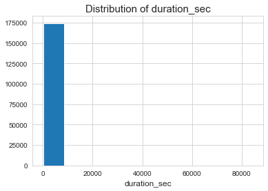

```python
hist(bike, 'duration_sec', None);
```

> The plot above does not relay much information as only one bar can be seen in the chart.

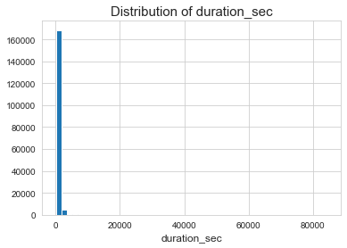

```python
hist(bike, 'duration_sec', 50);
```

> I made a few changes to this plot, I added a bin value of 50 and from the plot most of the values in the chart above appears to be less than 4,000 but still the chart doesn't still hold so much inforrmation other than the values are right-skewed.

```python
below4k = bike.query('duration_sec < 4000');
below4k.rename(columns={'duration_sec': 'duration below 4k'},
               inplace=True);
```

[output not shown]

> In the code cell above, I extracted the rows of each feature having their values for the _duration*sec* less than 4,000.

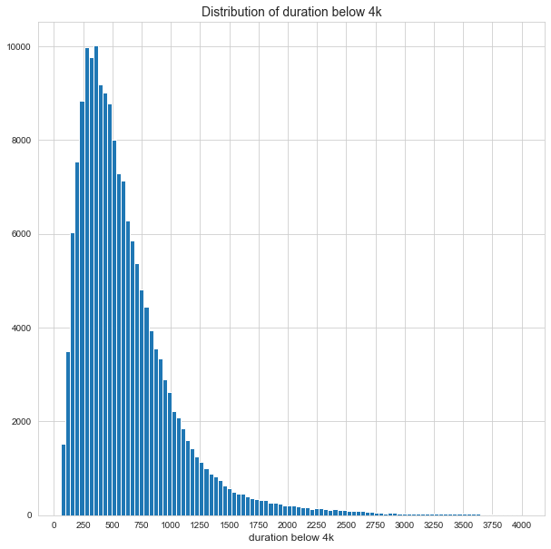

```python
plt.figure(figsize=(10, 10))
hist(data=below4k, x='duration below 4k', bins=100);
plt.xticks([0, 250, 500, 750, 1000, 1250, 1500, 1750, 2000, 2250, 2500, 2750, 3000, 3250, 3500, 3750, 4000],
           [0, 250, 500, 750, 1000, 1250, 1500, 1750, 2000, 2250, 2500, 2750, 3000, 3250, 3500, 3750, 4000]);
plt.title('Distribution of duration below 4k', size=14);
```

### **OBSERVATION**

> This plot shows a clearer view of the values in the feature and from that is a right skewed histogram showing a decrease in the values of the time(seconds) spent riding a bike, having its peak value in an estimated time of 375 seconds. This mean that many of the bikers could ride an estimated time of 375 seconds, this chart also showed that after the estimated 375 seconds the duration of rides started to decrease. **This can be due to the fact that few people travelled long distance using the bicycle and might have used other means of transportation.**

The _member_birth*year* is also an interesting column to check, as later on in the project I will like to know if the age will cause members to or not to complete their trip using bike-sharing system.

### **QUESTION:**

**WHICH AGE GROUP USE THE BIKE-SHARING SYSTEM THE MOST?**

### **VISUALIZATION**

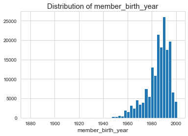

```python
hist(bike, 'member_birth_year', 50);
```

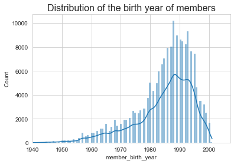

```python
color = sns.color_palette()[0]
sns.histplot(bike['member_birth_year'], kde=True, color=color, bins=200);
plt.title('Distribution of the birth year of members', fontdict={'size':16});
plt.xlim(left=1940);
```

### **OBSERVATION**

> The chart showed an increasing birth year for the members, which is a decrease in the age of the members using the bike-sharing system and with that, the count frequency increased - younger people use the bike-sharing system the most.

Now a look into the features with object as their datatype.

```python
def count(data, x):
    sns.countplot(x=x, data=data);
    plt.title(f'Proportion of unique values in {x}', size=14)
```

> I will be using the *countplot* function from the *seaborn* library to check distribution/proportion of unique values in each feature with the object datatype.

### **QUESTION:**

**ARE THERE MORE CUSTOMERS TO SUBSCRIBERS OR VICE-VERSA?**

### **VISUALIZATION**

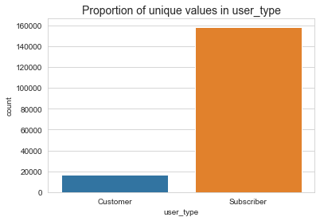

```python
count(bike,'user_type',)
```

### **OBSERVATION**

> The above chart shows the distribution of the values in the _user*type* column and from the plot we see two values - *Customer* and *Subscriber*, the plot tells us that there are more *Subscribers* than *Customers*.

### **QUESTION:**

**WHICH GENDER USE THE BIKE-SHARING SYSTEM THE MOST?**

### **VISUALIZATION**

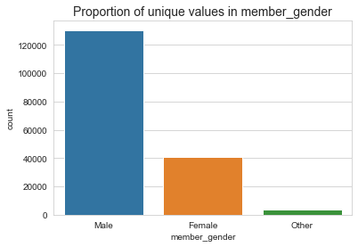

```python
count(bike, 'member_gender')
```

### **OBSERVATION**

> The distribution of the gender shows more, this might be due to males populating the area more or can also be to the fact that more males will have interest in riding a bike.

### **QUESTION:**

**DO MOST MEMBERS COMPLETE THEIR TRIP USING THE BIKES?**

### **VISUALIZATION**

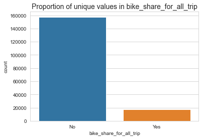

```python
count(bike, 'bike_share_for_all_trip')
```

### **OBSERVATION**

> From the chart above we see that there is a higher proportion of people who didn't complete their trip using the bike to the individuals that completed the trip using the bikes.

## **BIVARIATE EXPLORATION**

> In this section of the bike-sharing system project, I will be examining two features(bivariate visualization) to show relationship and derive insights from the features.

> My first plot will be examining the relationship between the _member_birth*year* and the _duration*sec* feature.

### **QUESTION:**

**DO OLDER MEMBERS SPEND MORE TIME ON THE BIKES?**

### **VISUALIZATION**

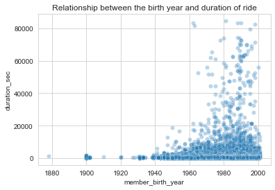

```python
sns.scatterplot(x='member_birth_year', y='duration_sec', data=bike, alpha=0.3);
plt.title('Relationship between the birth year and duration of ride');
```

### **OBSERVATION**

> Interstingly this plot follows my pattern of thinking, the individuals with wider range from the maximum tick value displayed on the chart should spend less time on the bikes. **In summary, the older ones spend lesser time using the bikes while the younger ones spend more time on the bikes.**

### **QUESTION:**

**WHICH GENDER HAVE THE HIGHEST MAXIMUM, AVERAGE AND MINIMUMU VALUE FOR THE BIRTH YEAR?**

```python
# function to make boxplot
def box(x, y, data, sym):
    sns.boxplot(x=x, y=y, data=data, sym=sym);
```

### **VISUALIZATION**

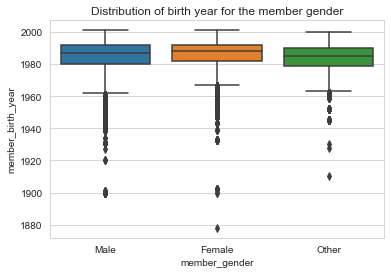

```python
box(x='member_gender', y='member_birth_year', data=bike, sym=None);
plt.title('Distribution of birth year for the member gender');
```

> The chart above shows the descriptive statistics of the values in the _member_birth*year* grouped by the _member*gender* column, the above chart tells that both the male and the female gender both have the maximum value for the year, also it shows that the female gender have the highest average value for year.

> Considering outliers in the chart the female gender have the minimum value of year.

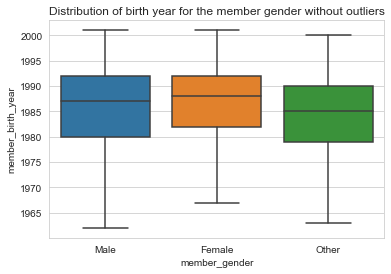

```python
box(x='member_gender', y='member_birth_year', data=bike, sym='')
plt.title('Distribution of birth year for the member gender without outliers');
```

### **OBSERVATION**

> Both the male and female gender have the maximum value for the year, the female gender having the highest average mean and with outliers the female gender have the minimum value. With the outliers removed from the plot the male gender have the minimum value of year.

### **QUESTION**

**DOES THE DURATION OF THE TRIP AFFECT COMPLETING THE TRIP?**

### **VISUALIZATION**

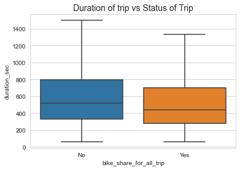

```python
box(x='bike_share_for_all_trip', y='duration_sec', data=bike, sym='');
plt.title('Duration of trip vs Status of Trip', size=14);
```

### **OBSERVATION**

> Trips requiring more time can be hectic and this might members not to complete their trip, just as the plot above have shown - longer duration trip affects the trip.

### **QUESTION:**

**WHICH GENDER HAVE A HIGHER COMPLETION RATE USING THE BIKE?**

```python
# function to make countplot with hue
def counth(data, x, hue):
    sns.countplot(x=x, data=data, hue=hue);
    plt.title(f'Proportion of {x} by {hue}', size=14);
```

### **VISUALIZATION**

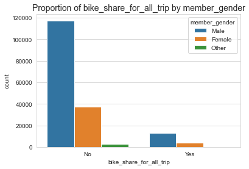

```python
counth(bike, 'bike_share_for_all_trip', hue='member_gender')
```

### **OBSERVATION**

> Interestingly, the male gender have both the highest rate for finishing the trip and not finishing the trip using the bike-sharing system.

### **QUESTION:**

**WHICH PROPORTION OF THE USER TYPE IS HIGHER FOR THE GENDER?**

### **VISUALIZATION**

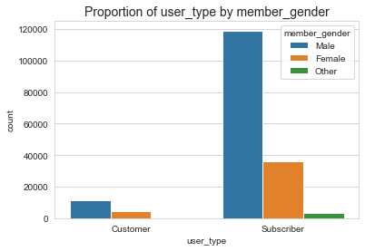

```python
counth(x='user_type', hue='member_gender', data=bike);
```

### **OBSERVATION**

> The male gender have the highest proportion in both values of the feature.

### **QUESTION**

**WHICH FEATURES HAVE THE HIGHEST CORRELATION TO ANOTHER?**

### **VISUALIZATION**

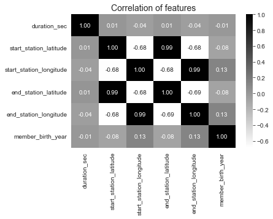

```python
num_feat = bike[['duration_sec', 'start_station_latitude', 'start_station_longitude',
                 'end_station_latitude', 'end_station_longitude', 'member_birth_year',]]

sns.heatmap(data=num_feat.corr(), annot=True, fmt='0.2f', cmap='gist_gray_r');
plt.title('Correlation of features', size=14);
```

### **OBSERVATION**

> Surprisingly there are negatively correlated features in the data set but the question reads *which feature have the highest correlation to another* and this can be seen from the plot that there are four features that correlate with a values of 0.99.

## **MULTIVARIATE EXPLORATION**

> More than two features will be examined in this section of the bike-sharing system project.

### **QUESTION**

**WHICH AGE GROUP OF PEOPLE SPENT MORE TIME USING THE BIKES AND COMPLETED THE TRIP?**

### **VISUALIZATION**

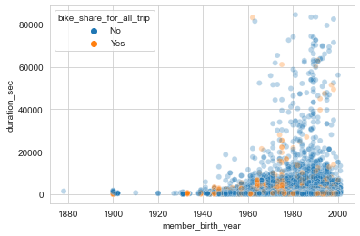

```python
sns.scatterplot(x='member_birth_year', y='duration_sec', data=bike, alpha=0.3, hue='bike_share_for_all_trip');
```

> I can't derive reasonable information from this plot, in other to make it more explanatory I will facet the plot.

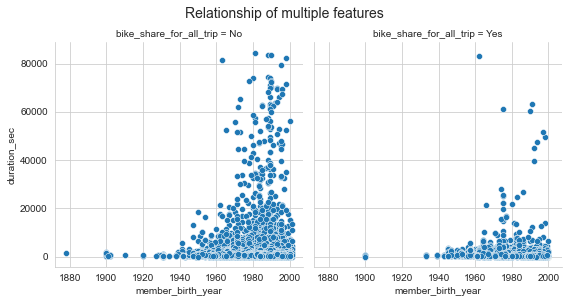

```python
g = sns.FacetGrid(data=bike, col='bike_share_for_all_trip', height=4);
g.map(sns.scatterplot, 'member_birth_year', 'duration_sec');
plt.suptitle('Relationship of multiple features', y=1.04, size=14);
```

### **OBSERVATION**

```python
# function to make boxplot with hue
def boxh(x, y, data, hue, sym):
    sns.boxplot(x=x, y=y, data=data, hue=hue, sym=sym);
```

### **VISUALIZATION**

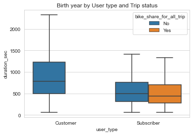

```python
boxh(x='user_type', y='duration_sec',
            data=bike, hue='bike_share_for_all_trip', sym='');
plt.title('Birth year by User type and Trip status');
```

### **OBSERVATION**

> Here we see that the user type affects the completion of trips using bike, from the plot we see that not one customer completed their trip using bike.

### **QUESTION**

**WHICH GENDER SPENT MORE TIME ON THE BIKE AND COMPLETED THE TRIP?**

### **VISUALIZATION**

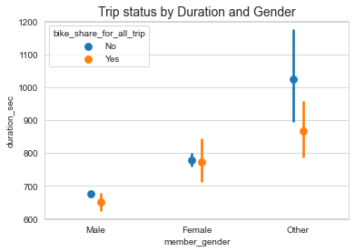

```python
sns.pointplot(data=bike, x='member_gender', y='duration_sec',
              hue='bike_share_for_all_trip', linestyles='', dodge=0.1);
plt.title('Trip status by Duration and Gender', size=14);
```

## **SAVINGS WRANGLED DATA**

> Since the plots in this project were made with cleaned data, I saved the clean data to another file, to use in the part 2 of the project.

```python
bike.to_csv('bikes.csv', index=False)
```

```python
bikes = pd.read_csv('bikes.csv')
bikes.head(2)
```

|  | duration_sec | start_time | end_time | start_station_id | start_station_name | start_station_latitude | start_station_longitude | end_station_id | end_station_name | end_station_latitude | end_station_longitude | bike_id | user_type | member_birth_year | member_gender | bike_share_for_all_trip |
| --- | --- | --- | --- | --- | --- | --- | --- | --- | --- | --- | --- | --- | --- | --- | --- | --- |
| 0 | 52185 | 2019-02-28 17:32:10.145 | 2019-03-01 08:01:55.975 | 21.0 | Montgomery St BART Station (Market St at 2nd St) | 37.789625 | -122.400811 | 13.0 | Commercial St at Montgomery St | 37.794231 | -122.402923 | 4902 | Customer | 1984.0 | Male | No |
| 1 | 61854 | 2019-02-28 12:13:13.218 | 2019-03-01 05:24:08.146 | 86.0 | Market St at Dolores St | 37.769305 | -122.426826 | 3.0 | Powell St BART Station (Market St at 4th St) | 37.786375 | -122.404904 | 5905 | Customer | 1972.0 | Male | No |

### **Talk about some of the relationships you observed in this part of the investigation. Were there features that strengthened each other in terms of looking at your feature(s) of interest?**

> From the visualizations I did, I found out that certain features help bring out meaning when plotted with other features. Features like the duration_sec - helped to know members tend to complete trips with shorter duration than the longer ones, member_gender - this showed that the *Other* gender travelled the highest-completed duration.

### **Were there any interesting or surprising interactions between features?**

> Interestingly, some of the plots followed the expected outcome like expecting less individuals to spend a long time using the bike. Condidering the population of *Males* using the bike-sharing system, the most surprising interaction is this project for me is the *Other* gender getting the highest-completed duration.

## **CONCLUSIONS**

> From investigation and exploration on the data set, I found out that the rate of completion of the trip using the bike-sharing system depends on certain features, this features includes - member_birth_year, member_gender, duration_sec, user_type etc.

> From the viz in my project, I can clearly state that duration of the trip affects as trips having longer duration are not completed. Also, the member_birth_year affect the trips and again the gender of the individual affects the trips.